# Reproducible Research: Peer Assessment 1

## Loading and preprocessing the data

```r
library(knitr)
data <- read.csv("activity.csv", header = TRUE)
```

### Plot histgram of total steps taken each day

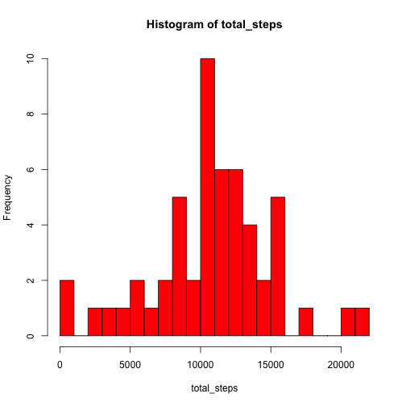

```r
total_steps <- tapply(data$steps, as.factor(data$date), sum)
hist(total_steps, 20, col = "red")
```

```r
steps_mean <- mean(total_steps, na.rm = TRUE)
steps_median <- median(total_steps, na.rm = TRUE)
```

## What is mean total number of steps taken per day?

The mean total number of steps taken per data is 1.0766 × 10<sup>4</sup> .  
The median total number of steps taken per data is 10765.

## What is the average daily activity pattern?

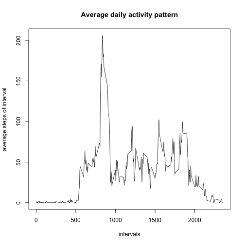

```r
interval_avrg_steps <- tapply(data$steps, as.factor(data$interval), mean, na.rm = TRUE)
interval <- as.numeric(data$interval[1:288])
plot(interval, interval_avrg_steps, type = "l", xlab = "intervals", ylab = "average steps of interval",
    main = "Average daily activity pattern")
```

```r
max_index <- which(interval_avrg_steps == max(interval_avrg_steps))
max_interval <- data$interval[max_index]
```

According to Average daily activity pattern plot above, 835 has the maximum number of steps in all the 5-minute interval.

## Imputing missing values

The total number of missing values in dataset is 2304. Strategy for filling in all the missing values in dataset is to fill in mean of interval  
average steps as missing values.

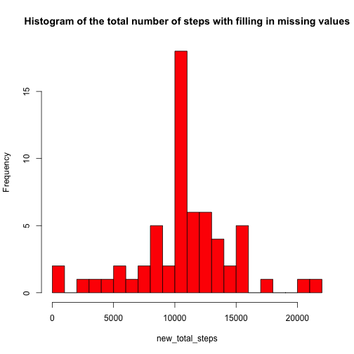

```r
data_new <- data
for (i in 1:dim(data)[1]) {
    if (is.na(data$steps[i])) {
        which_interval <- which(interval == data$interval[i])
        data_new$steps[i] <- interval_avrg_steps[which_interval]
    }
}

# make a histogram of the total number of steps taken each day and calculate
# mean and median of each day
new_total_steps <- tapply(data_new$steps, as.factor(data$date), sum)
hist(new_total_steps, 20, col = "red", main = "Histogram of the total number of steps with filling in missing values")
```

```r
new_steps_mean <- mean(new_total_steps, na.rm = TRUE)
new_steps_median <- median(new_total_steps, na.rm = TRUE)
```

After filling in missing values with average of the corresponding interval across each day, the new histogram is shown above. The new mean of total number of steps stays the same 1.0766 × 10<sup>4</sup> and the new median becomes the same as the new mean from 10765.

## Are there differences in activity patterns between weekdays and weekends?

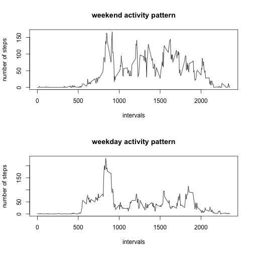

```r
for (i in 1:dim(data_new)[1]) {
    temp <- weekdays(strptime(data_new$date[i], "%Y-%m-%d"))
    if (temp == "Saturday" | temp == "Sunday") {
        data_new$weekday[i] <- "weekend"
    } else {
        data_new$weekday[i] <- "weekday"
    }

}
temp <- data_new$weekday == "weekend"
weekend_data <- data_new[temp, c(1, 3)]
weekday_data <- data_new[!temp, c(1, 3)]
par(mfrow = c(2, 1))
weekend_avrg <- tapply(weekend_data[, 1], as.factor(weekend_data[, 2]), mean)
weekday_avrg <- tapply(weekday_data[, 1], as.factor(weekday_data[, 2]), mean)
plot(interval, weekend_avrg, type = "l", xlab = "intervals", ylab = "number of steps",
    main = "weekend activity pattern")
plot(interval, weekday_avrg, type = "l", xlab = "intervals", ylab = "number of steps",
    main = "weekday activity pattern")
```

Comparing weekend activity pattern with weekday activity pattern, as shown above, we can see that the weekend activity pattern is different from weekday activity pattern. According to the plots, the subject gets up earlier in the weekdays' morning than in the weekend's morning. The subject may stay in his or her office after 10:00 am during weekdays while he or she has more activities in weekends. The third different pattern is the time that the subject goes to bed at nights between weekends and weekdays.